# supervised

## Load the corpus

We use a labeled Movie Review Dataset to implement a simple supervised machine learning approach. The dataset contains 5,331 positive and 5,331 negative processed sentences from Rotten Tomatoes movie reviews. Our goal is to train a classifier that can predict whether a sentence is positive or negative.

This data was first used in Bo Pang and Lillian Lee, ``Seeing stars: Exploiting class relationships for sentiment categorization with respect to rating scales.’’, Proceedings of the ACL, 2005. Please find more information on the dataset here. https://huggingface.co/datasets/rotten_tomatoes

Data labeling: “the movie-review “snippets” (a striking extract usually one sentence long) downloaded from www.rottentomatoes.com; each snippet was labeled with its source review’s label (positive or negative) as provided by Rotten Tomatoes.” (Pang & Lee, 2005) p.119)

```r
setwd("~/Desktop/Teaching/CEU_text_analysis_25/meeting_7")

library(tidyverse)
reviews <- read_csv("reviews.csv")
```

## Inspect the data

```r
colnames(reviews)
```

```
## [1] "value"    "polarity"
```

```r
names(reviews)[names(reviews) == 'value'] <- 'text' #give the column with the text a useful name
class(reviews$text)
```

```
## [1] "character"
```

```r
table(reviews$polarity) #check the distribution of the outcome variable
```

```
##
## negative positive
##     5331     5331
```

```r
class(reviews$polarity)
```

```
## [1] "character"
```

We now work with the R package quanteda. Please check out the following tutorials specifically for machine learning.

https://content-analysis-with-r.com/5-machine_learning.html https://tutorials.quanteda.io/basic-operations/corpus/corpus/

Create a corpus and look at a summary.

```r
# install.packages("quanteda")

library(quanteda)
reviews_corpus <- corpus(reviews)
summary(reviews_corpus, 5)
```

```
## Corpus consisting of 10662 documents, showing 5 documents:
##
##   Text Types Tokens Sentences polarity
##  text1    31     34         1 positive
##  text2    31     41         1 positive
##  text3     4      4         1 positive
##  text4    18     21         1 positive
##  text5    21     21         1 positive
```

```r
# create docvar with ID
reviews_corpus$id_numeric <- 1:ndoc(reviews_corpus)
summary(reviews_corpus, 5)
```

```
## Corpus consisting of 10662 documents, showing 5 documents:
##
##   Text Types Tokens Sentences polarity id_numeric
##  text1    31     34         1 positive          1
##  text2    31     41         1 positive          2
##  text3     4      4         1 positive          3
##  text4    18     21         1 positive          4
##  text5    21     21         1 positive          5
```

Create a vector which includes the ids for the training part (here 80%) and for the test data (here 20%). We randomly select the 80%. The remaining reviews are assigned as test cases. Once we have the DFM, we split it into training and test set. We’ll go with 80% training and 20% set. Note the use of a random seed to make sure our results are replicable.

```r
set.seed(333)

id_train <- sample(1:nrow(reviews), floor(.80 * nrow(reviews)))
id_test <- (1:nrow(reviews))[1:nrow(reviews) %in% id_train == FALSE]
```

tokenize texts and represent as dfm

```r
toks_reviews <- tokens(reviews_corpus, remove_punct = TRUE, remove_number = TRUE) %>%
               tokens_remove(pattern = stopwords("en")) %>%
               tokens_wordstem()

dfm_reviews <- dfm(toks_reviews)
dfm_reviews
```

```
## Document-feature matrix of: 10,662 documents, 13,955 features (99.93% sparse) and 2 docvars.
##        features
## docs    rock destin 21st centuri new conan go make splash even
##   text1    1      1    1       1   1     1  1    1      1    1
##   text2    0      0    0       0   0     0  0    0      0    0
##   text3    0      0    0       0   0     0  0    0      0    0
##   text4    0      0    0       0   0     0  1    0      0    0
##   text5    0      0    0       0   0     0  0    0      0    0
##   text6    0      0    0       0   0     0  0    0      0    1
## [ reached max_ndoc ... 10,656 more documents, reached max_nfeat ... 13,945 more features ]
```

```r
dfm_reviews_trim <- dfm_trim(dfm_reviews, min_docfreq = 2, verbose=TRUE) # remove words that appear in less than 2 documents
```

```
## dfm_trim() changed from 13,955 features (10,662 documents) to 7,554 features (10,662 documents)
```

```r
dfm_reviews_trim
```

```
## Document-feature matrix of: 10,662 documents, 7,554 features (99.87% sparse) and 2 docvars.
##        features
## docs    rock destin 21st centuri new conan go make splash even
##   text1    1      1    1       1   1     1  1    1      1    1
##   text2    0      0    0       0   0     0  0    0      0    0
##   text3    0      0    0       0   0     0  0    0      0    0
##   text4    0      0    0       0   0     0  1    0      0    0
##   text5    0      0    0       0   0     0  0    0      0    0
##   text6    0      0    0       0   0     0  0    0      0    1
## [ reached max_ndoc ... 10,656 more documents, reached max_nfeat ... 7,544 more features ]
```

Split the dfm in two parts, a training and a test part.

```r
# get training set
dfm_train <- dfm_subset(dfm_reviews_trim, id_numeric %in% id_train)


# get test set (by using the ! you indicate that you select documents not in id_train)
dfm_test <- dfm_subset(dfm_reviews_trim, !id_numeric %in% id_train)
```

# Training

Fit a Naïve Bayes Classifier on the training dfm and save the learned model in the object ‘model.NB’. The Naïve Bayes Classifier is part of the library quanteda.textmodels.

```r
# install.packages("quanteda.textmodels")
library(quanteda.textmodels)
model_nb <- textmodel_nb(dfm_train, dfm_train$polarity, prior = "docfreq") #Prior distributions refer to the prior probabilities assigned to the training classes
```

Fit a Linear SVM classifier on the training dfm and save the learned model in the object ‘model.svm’.

```r
model_svm <- textmodel_svmlin(dfm_train, dfm_train$polarity)
```

# Predict for the test set

```r
pred_nb <- predict(model_nb, dfm_test, force = TRUE) # force = True will force your test data to give identical features (and ordering of features) to the training set
```

```r
summary(pred_nb)
```

```
## negative positive
##     1065     1068
```

```r
summary(model_nb)
```

```
##
## Call:
## textmodel_nb.dfm(x = dfm_train, y = dfm_train$polarity, prior = "docfreq")
##
## Class Priors:
## (showing first 2 elements)
## negative positive
##   0.5013   0.4987
##
## Estimated Feature Scores:
##               rock    destin      21st   centuri     new     conan       go
## negative 0.0002834 0.0002024 6.073e-05 0.0001417 0.00166 2.024e-05 0.001842
## positive 0.0002983 0.0001988 7.953e-05 0.0002585 0.00169 5.965e-05 0.001372
##              make    splash     even   greater    arnold schwarzenegg
## negative 0.004595 8.098e-05 0.003462 6.073e-05 1.822e-04    1.417e-04
## positive 0.005130 1.193e-04 0.003042 1.193e-04 5.965e-05    3.977e-05
##          jean-claud       van      damm    steven  gorgeous    elabor   continu
## negative  4.049e-05 1.012e-04 4.049e-05 0.0002429 0.0001417 1.620e-04 0.0001822
## positive  3.977e-05 7.953e-05 3.977e-05 0.0002784 0.0005766 3.977e-05 0.0003579
##               lord      ring    trilog      huge    column      word     adequ
## negative 6.073e-05 0.0002429 4.049e-05 0.0001620 4.049e-05 0.0004049 1.417e-04
## positive 7.953e-05 0.0002386 7.953e-05 0.0003778 3.977e-05 0.0003579 9.942e-05
##            describ   co-writ director
## negative 0.0002024 6.073e-05 0.002207
## positive 0.0001193 1.392e-04 0.002366
```

```r
pred_svm <- predict(model_svm, dfm_test, force = TRUE) # force = True will force your test data to give identical features (and ordering of features) to the training set
```

Add the labels predicted by the model to the initial dataframe. Name the new column polarity_ml.

```r
colnames(reviews)
```

```
## [1] "text"     "polarity"
```

```r
reviews$id <- 1:nrow(reviews)
reviews_test <- subset(reviews, id %in% id_test)
reviews_test$polarity_nb <- pred_nb
colnames(reviews_test)
```

```
## [1] "text"        "polarity"    "id"          "polarity_nb"
```

Let’s add another column to the dataframe with the svm prediction

```r
reviews_test$polarity_svm <- pred_svm
colnames(reviews_test)
```

```
## [1] "text"         "polarity"     "id"           "polarity_nb"  "polarity_svm"
```

save result

```r
# setwd() # set your working directory to week_7 folder

write_csv(reviews_test, "rotten_tomatoes_nb_svm_test.csv")

reviews_train <- subset(reviews, id %in% id_train)
reviews_train$polarity_nb <- NA
reviews_train$polarity_svm <- NA
write_csv(reviews_train, "rotten_tomatoes_nb_svm_train.csv")

reviews_all <- rbind(reviews_test, reviews_train)
write_csv(reviews_all, "rotten_tomatoes_nb_svm.csv")
```

## Compare automated with manual classifications

We compare the automated classification (in column `polarity_nb`) with the manual classifications (in column `polarity`) we use three metrics: Recall, Precision, and F1. The metrics inform us about the quality of the classifier. All three metrics range from 0 to 1.

# Recoding

First we bring the data into the numeric format.

```r
reviews_test <- reviews_test %>%
    mutate(polarity = case_when(
      polarity == 'positive' ~ 1,
      polarity == 'negative' ~ 2
    ))

reviews_test <- reviews_test %>%
    mutate(polarity_nb = case_when(
      polarity_nb == 'positive' ~ 1,
      polarity_nb == 'negative' ~ 2
    ))

reviews_test <- reviews_test %>%
    mutate(polarity_svm = case_when(
      polarity_svm == 'positive' ~ 1,
      polarity_svm == 'negative' ~ 2
    ))
```

```r
metrics <- function(reviews_test, categ, model = c("nb", "svm")) {
  # Ensure the model argument is one of the allowed values
  model <- match.arg(model)

  # Select the predicted polarity column based on the model argument
  pred_col <- if (model == "nb") "polarity_nb" else "polarity_svm"

  # Create a 2x2 table comparing actual vs. predicted categorizations.
  # We mark as 1 if the actual/predicted value equals 'categ', else 0.
  results_table <- table(
    ifelse(reviews_test$polarity == categ, 1, 0),
    ifelse(reviews_test[[pred_col]] == categ, 1, 0)
  )

  # Calculate recall:
  # True Positives (TP) are results_table[2,2] and False Negatives (FN) are results_table[2,1].
  recall <- results_table[2, 2] / (results_table[2, 2] + results_table[2, 1])

  # Calculate precision:
  # True Positives (TP) are results_table[2,2] and False Positives (FP) are results_table[1,2].
  precision <- results_table[2, 2] / (results_table[2, 2] + results_table[1, 2])

  # Calculate F1 score (harmonic mean of precision and recall)
  f1 <- 2 * recall * precision / (recall + precision)

  # Return the metrics as a named vector
  c(precision = precision, recall = recall, f1 = f1)
}
```

### Package all per-class metrics in one matrix

```r
package_metrics <- function(data, n_classes) { #n_classes is the number of categories here 2 (negative and positive)
  res <- matrix(NA, n_classes, 3) #3 relates to three metrics here precision, recall and F1
  for (c in 1:n_classes) {
    res[c, ] <- metrics(data, c)
  }
  return(res)
}
```

### Compute average F1 for the polarity analysis task

```r
macro_f1_sent <- function(reviews_test){
  res_pos <- metrics(reviews_test,1) # Metrics for positive class
  res_neg <- metrics(reviews_test,2) # Metrics for negative class
  avg_f1 <- mean(c(res_pos[3], res_neg[3])) ## Calculate average F1 score
  avg_f1
  return(avg_f1)
}
```

### Compute accuracy

The diag() function extracts the diagonal elements of the contingency table, which correspond to the correctly predicted instances for each class.

The accuracy is then computed by dividing the sum of the correctly predicted instances by the total number of instances in the dataset (sum(res_table)).

```r
# accuracy <- function(reviews_sub){
#   res_table <- table(reviews_sub$polarity, reviews_sub$polarity_nb)
#   acc <- sum(diag(res_table))/sum(res_table)
#   return(acc)
# }


accuracy <- function(reviews_sub, model = c("nb", "svm")){
  # Match the model argument to one of the allowed values
  model <- match.arg(model)

  # Select the column name based on the model argument
  col_name <- if(model == "nb") "polarity_nb" else "polarity_svm"

  # Create a confusion matrix between the true polarity and the predicted polarity
  res_table <- table(reviews_sub$polarity, reviews_sub[[col_name]])

  # Calculate accuracy as the sum of the diagonal divided by the total number of cases
  acc <- sum(diag(res_table)) / sum(res_table)
  return(acc)
}
```

### Plot and save confusion matrix

The function calculates the confusion matrix, converts the counts to proportions, and creates a dataframe with text labels. It then uses the ggplot2 package to generate the heatmap plot with tiles representing the proportions and text labels showing the rounded values. The plot is customized with appropriate labels, title, legend, and color gradient.

color: The color scheme for the heatmap. You can specify a color name or a hex code.

```r
plot_conf_mat <- function(reviews_test, color){ # can set the wanted color
  # data might need to be formatted to go from numbers to text labels - see remodeling function
  conf_mat <- table(reviews_test$polarity, reviews_test$polarity_nb)

  conf_mat <- conf_mat / rowSums(conf_mat)

  conf_mat <- as.data.frame(conf_mat, stringsAsFactors = TRUE)

  p <- ggplot(conf_mat, aes(Var1, Var2, fill = Freq)) +
    geom_tile() +
    geom_text(aes(label = round(Freq,2))) +
    labs(x = "True labels", y = "Predicted labels", #title = "Confusion matrix of GPT-4 on English sentiment",
         fill = "Proportion") +
    theme(plot.title = element_text(size = 16, hjust = 0.5),
          legend.title = element_text(size = 12),
          axis.title.x = element_text(size = 12),
          axis.title.y = element_text(size = 12),
          legend.key.size = unit(1, 'cm')
    ) +
    scale_fill_gradient(low="white", high=color, limits = c(0,1))

  return(p)
}
```

### Run functions

Precision, recall, F1

```r
res_pos_sent <- metrics(reviews_test, 1, 'nb') # precision, recall, F1 for the 'positive' label in sentiment analysis
res_pos_sent
```

```
## precision    recall        f1
## 0.7584270 0.7513915 0.7548928
```

```r
res_neg_sent <- metrics(reviews_test, 2, 'nb') # precision, recall; F1 for the 'negative' label in sentiment analysis
res_neg_sent
```

```
## precision    recall        f1
## 0.7483568 0.7554502 0.7518868
```

Results: svm [1] 0.7283127 0.7120224 0.7200754 [1] 0.7149446 0.7311321 0.7229478

matrix with metrics for polarity analysis

```r
res_sent <- package_metrics(reviews_test, 2)
res_sent
```

```
##           [,1]      [,2]      [,3]
## [1,] 0.7584270 0.7513915 0.7548928
## [2,] 0.7483568 0.7554502 0.7518868
```

average F1

```r
avg_f1 <- macro_f1_sent(reviews_test)
avg_f1
```

```
## [1] 0.7533898
```

Results: SVM 0.7215116

accuracy

```r
acc_sent <- accuracy(reviews_test) #
acc_sent
```

```
## [1] 0.753399
```

create and save a heatmap plot of the confusion matrix

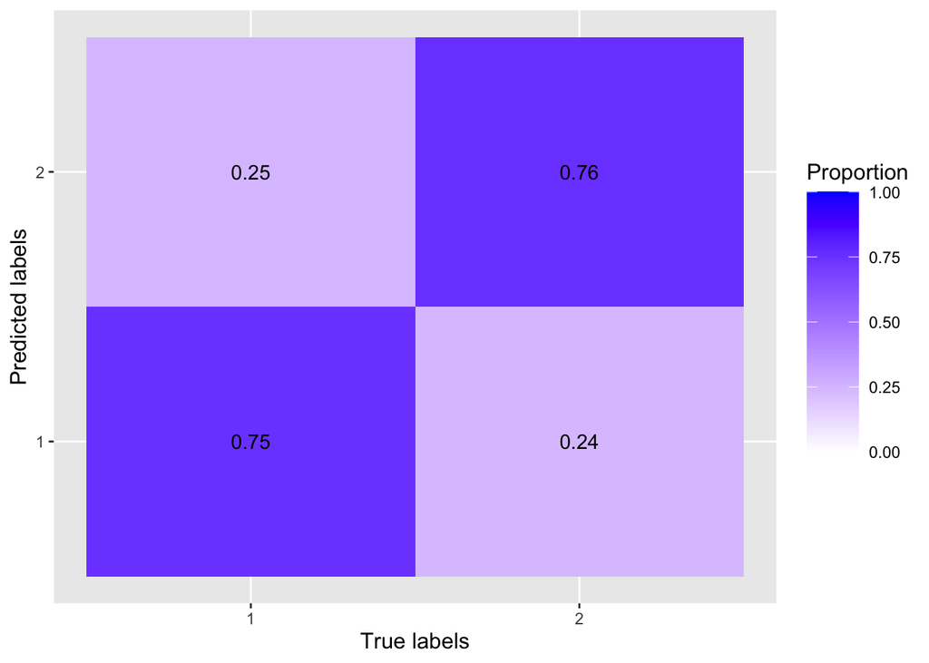

```r
plot_conf_mat(reviews_test, "blue")
```

# K-fold cross-validation

```r
# installed.packages("caret")
library(caret)
# we already have the document term matrix

dfm_reviews_trim
```

```
## Document-feature matrix of: 10,662 documents, 7,554 features (99.87% sparse) and 2 docvars.
##        features
## docs    rock destin 21st centuri new conan go make splash even
##   text1    1      1    1       1   1     1  1    1      1    1
##   text2    0      0    0       0   0     0  0    0      0    0
##   text3    0      0    0       0   0     0  0    0      0    0
##   text4    0      0    0       0   0     0  1    0      0    0
##   text5    0      0    0       0   0     0  0    0      0    0
##   text6    0      0    0       0   0     0  0    0      0    1
## [ reached max_ndoc ... 10,656 more documents, reached max_nfeat ... 7,544 more features ]
```

```r
set.seed(123)
# create a 10-fold cross-validation
folds <- createFolds(reviews$polarity, k = 10, list = TRUE)
```

## Perfom k-fold cross-validation

```r
# create a function to perform k-fold cross-validation
k_fold_cv <- function(folds, my_dfm, reviews, model, model_name) {
  results <- list()
  for (i in 1:length(folds)) {
    # get the training and test set

    train_idx <- unlist(folds[-i])
    test_idx <- unlist(folds[i])

    train <- my_dfm[train_idx, ]
    test <- my_dfm[test_idx, ]

    # fit the model
    model_fit <- model(train, train$polarity)

    # predict the test set
    pred <- predict(model_fit, test, force = TRUE)

    results[[i]] <- confusionMatrix(as_factor(pred), as_factor(test$polarity))

    cat("Fold ", i, " done\n")
  }

  cat(model_name, "model done\n")

  return(results)
}
```

```r
# perform k-fold cross-validation for the Naive Bayes model
output_nb <- k_fold_cv(folds, dfm_reviews_trim, reviews, textmodel_nb, "Naive Bayes")
```

```
## Fold  1  done
## Fold  2  done
## Fold  3  done
## Fold  4  done
## Fold  5  done
## Fold  6  done
## Fold  7  done
## Fold  8  done
## Fold  9  done
## Fold  10  done
## Naive Bayes model done
```

```r
# perform k-fold cross-validation for the SVM model
output_svm <- k_fold_cv(folds, dfm_reviews_trim, reviews, textmodel_svmlin, "SVM")
```

```
## Fold  1  done
## Fold  2  done
## Fold  3  done
## Fold  4  done
## Fold  5  done
## Fold  6  done
## Fold  7  done
## Fold  8  done
## Fold  9  done
## Fold  10  done
## SVM model done
```

```r
output_svm
```

```
## [[1]]
## Confusion Matrix and Statistics
##
##           Reference
## Prediction positive negative
##   positive      350      290
##   negative      183      243
##
##                Accuracy : 0.5563
##                  95% CI : (0.5259, 0.5864)
##     No Information Rate : 0.5
##     P-Value [Acc > NIR] : 0.000132
##
##                   Kappa : 0.1126
##
##  Mcnemar's Test P-Value : 1.094e-06
##
##             Sensitivity : 0.6567
##             Specificity : 0.4559
##          Pos Pred Value : 0.5469
##          Neg Pred Value : 0.5704
##              Prevalence : 0.5000
##          Detection Rate : 0.3283
##    Detection Prevalence : 0.6004
##       Balanced Accuracy : 0.5563
##
##        'Positive' Class : positive
##
##
## [[2]]
## Confusion Matrix and Statistics
##
##           Reference
## Prediction positive negative
##   positive      354      325
##   negative      179      208
##
##                Accuracy : 0.5272
##                  95% CI : (0.4967, 0.5575)
##     No Information Rate : 0.5
```

[output cut: 234 more lines]

```
##                   Kappa : 0.0844
##
##  Mcnemar's Test P-Value : 4.039e-14
##
##             Sensitivity : 0.6998
##             Specificity : 0.3846
##          Pos Pred Value : 0.5321
##          Neg Pred Value : 0.5616
##              Prevalence : 0.5000
##          Detection Rate : 0.3499
##    Detection Prevalence : 0.6576
##       Balanced Accuracy : 0.5422
##
##        'Positive' Class : positive
##
```

```r
get_results <- function(results) {
  overall_accuracy <- 0
  overall_precision <- 0
  overall_recall <- 0
  overall_f1 <- 0

  folds <- length(results)

  for (i in 1:folds) {
    cm <- results[[i]]

    accuracy <- cm$overall["Accuracy"]
    precision <- cm$byClass["Precision"]
    recall <- cm$byClass["Recall"]
    f1 <- cm$byClass["F1"]

    overall_accuracy <- overall_accuracy + accuracy
    overall_precision <- overall_precision + precision
    overall_recall <- overall_recall + recall
    overall_f1 <- overall_f1 + f1
  }

  average_accuracy <- overall_accuracy / folds
  average_precision <- overall_precision / folds
  average_recall <- overall_recall / folds
  average_f1 <- overall_f1 / folds

  return(c(average_accuracy, average_precision, average_recall, average_f1))
}
```

```r
results_nb <- get_results(output_nb)

results_svm <- get_results(output_svm)

results_nb
```

```
##  Accuracy Precision    Recall        F1
## 0.7690861 0.7699342 0.7677752 0.7687232
```

```r
results_svm
```

```
##  Accuracy Precision    Recall        F1
## 0.5363908 0.5285209 0.6775488 0.5936456
```